# Final Report

May 6th, 2025

# From Subculture To Mainstream: Examining Anime’s Transformation From Microculture Into Global Mainstream Through User Engagements

# Abstract

The anime culture has become a global phenomenon that significantly influences popular culture and shapes the entertainment industry worldwide with skyrocketed revenues and unprecedented international growth in recent years. Streaming services in particular have significantly improved anime across the world and fostered a gigantic fanbase globally, which is expected to contribute “a compound annual growth rate of 10.20% from 2023 to 2030” in international licensing and merchandising (Bali, 2025). This paper will examine the key factors of anime’s global market expansion through “anime content creations and distributions” and analyze their implications for stakeholders and investors as well as regular anime fans (Shinde, 2024). Thus, this project aims to provide content creators, investors, and anime fans with a deeper understanding of anime’s expanding economic footprint and “significant investment opportunities” as anime characters and series emerge in this global industry (Shinde, 2024).

# Introduction

## The Origin Of Anime

Anime refers to a “distinct style of animation” that originates from Japan, which is characterized by colorful art, vibrant characters, and fantastical themes (Razak, 2025). With a wide range of genres for different age groups and interests, the anime industry is witnessing rapid advancements in animation technology, including CGI and VR, which enhance storytelling. New narrative styles like “interactive anime” are also attracting diverse audiences and pushing creative boundaries (Razak, 2025). What was once considered a microculture has become a “multibillion-dollar market” that has a major impact on various industries with a broad international audience (Dyck, 2024).

Over the decades, anime styles have changed drastically from the “simplistic designs” of early works to the “intricate animation seen” in popular titles; these advancements in digital animation have allowed the anime culture for better visuals and complex character designs (Dyck, 2024). Hence, anime’s increasing popularity has led to a rise in international collaborations, which allows for the adaptation of anime to different cultures and fosters a “diverse range of stories and characters” (Razak, 2025).

## Anime’s Cultural Impact

Anime’s cultural influence has grown remarkably over the past several decades. As Japan’s “greatest cultural export”, anime is now deeply embedded in both Japanese and global popular culture (Pace-McCarrick, 2021). In Japan, animated characters and narratives permeate everyday life from themed cafes and public transit to government campaigns leveraging characters for public messaging. Even as early as the 1960s and 1970s, anime and manga were intertwined with real world events. For instance, popular anime and manga heroes became “symbols during Japanese student protest movements” during that time period (Pace-McCarrick, 2021). Anime’s cultural impact also extends to social and political spheres as the fan activities have advanced both social movements and identity politics. For example, feminist and LGBTQ+ groups have found “representations” in certain anime narratives and characters as symbols in protests or advocacy campaigns (Fennell et al., 2013).

In recent years, images of heroines from anime have appeared on placards during women’s marches and references to freedom fighting anime storylines have been used to communicate solidarity in global protest movements. This diverse fan base has given rise to anime inspired art, music, and online discourse that blend Japanese pop culture with local cultural expressions. Furthermore, anime’s cultural impact is evident as how it has shaped media, fashion, language, and social trends worldwide. Western entertainment has drawn inspiration from anime’s distinctive aesthetics and storytelling since many creators have openly cited anime as a “major influence on their work” where anime style can be seen in everything from action cinema to American cartoons (Mash, 2024).

Hence, all these examples illustrate anime’s cultural influence as it shapes how people around the world and forsters a shared global story and style. With anime fandom increasingly normalized and celebrated as part of Japan’s modern cultural identity, the Japanese government has even incorporated anime into its cultural diplomacy to project soft power abroad (Iwabuchi, 2002). Thus, these developments underscore anime’s transition from a microculture into a popular mainstream culture across the world.

## The Expansion of Anime Culture

By the late 2000s, the anime industry and global media companies began catching up with the fervor of the fanbase. The internet and dedicated streaming platforms revolutionized access to anime because viewers around the world could suddenly watch new episodes almost immediately after their Japanese airing rather than using tapes or DVDs. As one of the largest streaming sites in the U.S., Hulu began hosting subtitled anime in September 2008 with the launch of its “channel for free, legal anime streams” while the other popular anime service like Crunchyroll made history in January 2009 by streaming Naruto Shippuden episodes after its Japanese television broadcast debut (Hulu, 2025).

Subsequently, more fan driven subculture blossomed around anime and has spread worldwide. One prominent example is cosplay, where fans dress up as characters from anime and related media. It has become a global phenomenon; enthusiasts at comic and anime conventions across North America, Europe, and Asia regularly cosplay their favorite characters with special costumes. This practice is more than dressing up because studies have found that cosplaying “serves as a therapeutic outlet for self-discovery”, which fosters social connections and provides stress relief among participants (Scottnicole, 2024). Cosplay meetups and contests like the World Cosplay Summit have been promoting global interaction attracting participants from over 30 countries.

As anime experienced explosive worldwide growth in recent years, streaming platforms have revolutionized anime by making anime more accessible to people around the world and distributing its merchandise to various audiences. Similarly, social media also amplifies anime’s reach because fans around the world can instantly share memes, fan art, and discussions about the latest episodes, which often leads to trending anime topics on Twitter or TikTok. For example, titles like Demon Slayer: Mugen Train has grossed over “$506,523,013 at the global box office” and became the highest gross generated anime film in history (Ferjan, 2024). Similarly, series like Attack on Titan has become phenomena since it broke multiple records across various streaming platforms.

In 2023, as the origin of anime, Japan’s animation industry generated “3.3 trillion” yen which is a 14% increase compared to previous years(Schley, 2024). Additionally, overseas markets now account for over half of this revenue, which drives anime’s popularity far beyond its origin. From action figures and cosplay costumes to fashion accessories, anime merchandise in retail stores worldwide further emphasize how these stories and characters have become part of the consumer’s everyday life. As a result, these successes highlight the commercial potential and cultural resonance of anime on a global scale.

# Motavitation

## Current Obstacles With Anime Market

Over the past two decades, anime has transited from late night TV slots and small conventions to global streaming homepages and trending topics across social media. This explosive growth leads to an unique connection between worldwide audiences with comments, critiques, memes, and merchandises in every new episode aired. However, with more than 300 new television titles and films debut each year, thousands of series remain in circulation, and social platforms generate millions of fan reactions within hours of release, viewers routinely ask a simple question of what should I watch next? Likewise, industry executives are facing a harder question of which anime will become the next global hit? As a result, both challenges stem from the issue of fragmented, rapidly changing information in the digital age.

## Improving Anime Fan Experience

For anime enthusiasts, our proposed platform serves as an informative and detailed anime hub that offers several key features:

- Comprehensive Information: Users can easily access detailed information on their favorite anime series, including summaries, character details, release schedules, and other insights.
- Personalized Recommendations: The app provides content suggestions based on each user’s preferences, which fans discover new series and movies aligned with their tastes.
- Better Content Discovery: Through intuitive exploration features, viewers can explore new shows and genres they might otherwise overlook, allowing them to try out different types of anime based on their personalized recommendations

## Improving Industry Stakeholders Experience

In addition to improving anime fans’ overall experience, the platform also serves as a powerful analytics tool for industry stakeholders such as investors, streaming services, and anime studios. Every anime could be translates into aggregated data that yields useful business insights:

- Audience Behavior Analytics: The application captures data on viewing habits and content preferences and illustrates which genres, characters, and themes resonate most with different audience segments.
- Market Trend Identification: Real time analytics highlight trending series and anime fan interests, which allow investors and producers to spot hits early and understand the factors driving their popularity.
- Targeted Marketing: Companies can execute more effective marketing campaigns based on those insights from the platform where stakeholders can quickly host promotional events or exclusive merchandise deals.

# Research Questions

As anime continues to expand its global footprint beyond its traditional markets, developing sophisticated analytical frameworks becomes crucial because such systematic analysis of anime consumption unveils broader cultural phenomena in digital entertainment ecosystems.

## The Relationship Between Animes Scores And Viewers

- What is the relationship between an anime’s score and its viewers?(Q1.1)Does the most watched anime also have the highest scores or mediocre series have highest viewership while popular series have average scores? By discovering the unique relationship between score and viewers, we hope to understand whether higher score indicates more viewers or factors like genres sometimes matter more than metrics like score and rank.
  - (Q1.2)Which anime are highly rated by the viewers who watch them but aren’t very popular overall? (Q1.3)Why these quality series didn’t reach a wider audience? (Q1.4)What do these shows have in common? (Q1.5)Are they older anime or do they all share specific similarities?
  - (Q1.6)Conversely, which anime attract huge viewership despite relatively lower scores? (Q1.7)For example, are there trending series that everyone watches but many consider them as average in terms of score?

## How Active Do Viewers Engage Based On Anime’s Popularity

- How actively viewers engage in discussing an anime based on its popularity? (Q2.1)Does a higher scored percentage indicate a more engaged or satisfied audience? (Q2.2)In other words, do anime with large shares of viewers who rated the show also tend to have higher popularity? By analyzing the underlying patterns between viewer engagement and anime score, we aim to understand whether an anime with just decent scores still becomes popular in terms of favorites ratio or vice versa?
  - (Q2.3)How does the score percentage, which is the proportion of viewers who rated the anime, change as the overall score increases? (Q2.4)Similarly, how does the favorited percentage, which is the proportion of viewers who favorited the anime, change as the overall score increases?
  - (Q2.5)Is there a strong correlation between an anime’s average score and its number of favorites or favorited percentage? (Q2.6)For instance, does high score anime also have a higher fraction of their viewers marking them as their favorite?

## What Are The Most Popular Genres Based On Scores And Views

- What genres are most strongly associated with high viewership and popularity? (Q3.1)Do certain genres have a track record of successful shows? By delving deep into this question, we plan to identify which genres streaming platforms might prioritize for a broad audience and whether certain genres inherently attract more viewers or higher scores.
  - (Q3.2)Is the inclusion of a popular genre like harem or shounen linked to significantly higher audience numbers? (Q3.3)Conversely, do certain genres like mecha or sports correlate with lower anime?
  - (Q3.4)Are there genres that consistently receive high anime scores or a lot of favorites despite not being the most widely watched? (Q3.5)For instance, do specific genres like slice of life or psychological thrillers get positive ratings from fans who do watch them even if their overall popularity ranking is moderate?

## The Correlation Between Top Tier Studios And High Score Anime

- Do certain studios consistently produce anime that achieve high scores? (Q4.1)How does the studio correlate with an anime’s quality reception? By exploring this question, we can find out how studios contribute to anime success and top tier studios that constant produce high quality and trending animes.
  - (Q4.2)Additionally, do lesser known studios sometimes surprise with breakout hits, or do their works generally stay lower in Rank and Score?
  - (Q4.3)Are anime from top studios more likely to have high scores or fan favorites? (Q4.4)Are there specific studios that are repeatedly making high score anime?

Understanding these patterns provides useful insights about the modern digital community and mainstream entertainment in an increasingly fragmented media landscape. Thus, these research questions seek to illuminate descriptive statistics about anime consumption as well as uncovering the underlying mechanisms that heavily affect anime culture and its impact across the world.

# Set Up

## Using Online Version

If you prefer not to install anything, you can access the Anime Statistics and Analysis Platform directly through your web browser by clicking the following link. Since the application is hosted online through Shinyapps.io, simply click that link and the app will load in your browser for immediate use. This is the easiest way to explore our platform because there are no setup, no downloads, and no technical steps needed.

https://qiranhu.shinyapps.io/AnimeStatisticsandAnalysisPlatform/

## Running Our Application Locally

If you want to run our platform on your own computer, then you can follow the step by step guide below. These instructions are designed to help users to set up our application on their devices locally. Since our system was developed using R version 4.1, we recommend using R 4.1+ for best compatibility. If you don’t have R yet, you can download it for free from the official R Project website. While not strictly required, it’s highly recommended to use RStudio which is a friendly interface for R that makes running Shiny apps easier. After setting up the environment, you can clone the repository located at https://github.com/illinois-stat447/sp25-prj-qiranhu2-wanjing4 using the command line. This will create a local copy of the project folder on your machine.

# Method

The design and implementation of the Anime Statistics and Analysis Platform are built using SQL, R and Shiny. Our methodology covers the full data science lifecycle from automated data acquisition to interactive visualization and machine learning predictive model. The project initiates with a thorough understanding of the challenging problems in the current anime market. By defining clear goals, identifying key performance indicators, and establishing success criteria, our project aims to deliver useful insights for both anime fans and industry stakeholders. With our innovative methods and features, we hope that our platform could effectively contribute to real world scenarios and enhance user experience.

## Data Acquisition

We developed our platform with a robust data acquisition pipeline to ensure comprehensive and real time anime information for analysis. The platform integrates directly with the MyAnimeList through its open sourced API link to programmatically fetch anime data. The unofficial RESTful API from MAL provides a complete dataset of anime entries including titles, genres, ratings, release dates, and more. By utilizing this unofficial RESTful API, our application automatically retrieves data on thousands of anime series and films in real time based on the user’s desire. We implemented pagination and asynchronous request handling to efficiently gather large result sets under Jikan’s rate limits, which is up to 60 requests per minute. This design choice minimizes initial load times and keeps the dataset current without manual updates. All fetched data is parsed from JSON responses into structured formats immediately upon receipt. By automating data collection through the API, the application ensures that users can always explore the latest available information.

Additionally, this dynamic data integration gives users greater flexibility. As new anime are added or existing records updated on MAL, our application can seamlessly incorporate those changes and deliver those content to the users. As a result, our data acquisition strategy emphasizes technical efficiency through caching and parallel requests. Since all the information comes straight from a well known source with constant updates, users can confidently base their insights on current and authoritative data.

## Data Preprocessing And Quality Control

Once the raw data is collected, our application performs an extensive data preprocessing to clean and transform the information into a more human readable format. Although MAL data is generally well structured and moderated, we enforce additional quality control steps to handle any inconsistencies or gaps. Initially, we address missing or null values by flagging them or setting them to 0 during the computation depending on the context of the attribute. We also normalize categorical fields to a consistent format, which involves standardizing naming conventions so that filters and comparisons treat equivalent values uniformly. Numerical fields are converted to proper numeric types and scaled if needed.

These preprocessing steps are implemented in our data pipeline, which means even tens of thousands of records can be cleaned within seconds. From a technical perspective, this ensures that the dataset remains clean, consistent, and optimized for users to access. From a user centered perspective, our platform provides reliable and easy to interpret information to everyone from technical users to regular anime fans since there are no distracting irregular entries or strange values that would confuse nontechnical users. Therefore, most of the columns are structured into easier formats, which lowers the barrier for users to derive insights without needing to perform their own data cleaning.

## Data Storage And Management

After our exhaustive data preprocessing, all the data are stored and managed in our SQL database with in memory database approach for rapid data retrieval, which persists data to local storage to avoid fetching from the API on each session. Hence, the platform loads the cleaned anime records into a structured data table; it allows users to query and filter with minimal delay as the application can find the data directly without additional calls. For instance, if users refresh the page, our application can reload the last saved dataset quickly instead of fetching from the API again. We carefully manage the memory footprint by only storing necessary fields and using efficient data structures so that even less powerful machines can run the platform smoothly. Whether a user is filtering the dataset by multiple criteria or paging through hundreds of entries, our application can respond at a relatively fast speed. Moreover, for non technical users, they do not have to worry about data files, formats, or database setup because the data is centrally managed by the platform, which is hidden behind the scenes. With up to date data and quick access, users can explore various anime without worrying about any tedious steps.

## Dynamic SQL Query

Our platform employs dynamic SQL querying to filter anime data in real time based on user selections. Instead of using a fixed query, our application programmatically builds tailored SQL SELECT statements with WHERE clauses based on the active filters. For example, if a user selects the comedy genre and sets a score range of 7 to 10, our system will generate a query that retrieves anime entries where the genre field contains comedy and the score is between 7 and 10. If multiple filters are chosen like selecting action and adventure genres with a minimum score of 8, the our system will include all corresponding conditions in the WHERE clause by combining them with logical operators such as AND or OR as appropriate. Furthermore, there will not be additional conditions added to the filters the user leaves blank or at default values; this means each query is as simple as possible while still encoding all active constraints, which results in minimal queries that the database can optimize more easily. The dynamic query construction ensures that filtering is flexible to any combination of user criteria since only the relevant subset of data is retrieved from the database for display. Therefore, this approach provides a foundation for interactive data exploration as each change in the UI immediately translates into an updated SQL query and hence an updated result set.

## SQL Based Filtering Design

Using SQL for filtering brings significant technical benefits to our application. By Performing the filtering within the SQLite database through SQL WHERE clauses, it is more efficient for large datasets than pulling all data into memory and filtering in application code. Another advantage of SQL based filtering is reduced memory usage on the application site. Since only the filtered results are returned, our system does not have to load the entire anime list into memory to then look through it. This design helps our application to scale better as the data grows since the backend can handle large query operations more gracefully than in-memory filtering. Hence, users can combine multiple filters and still get results in a few seconds. Thus, by incorporating filter operations in the SQL database, our platform achieves faster query responses and lower resource usage, which provides a smooth experience for all the users.

## Interactive Filtering UI Components

From the user’s perspective, our application provides user friendly interfaces with familiar GUI elements such as buttons, dropdowns, and sliders. Our filtering panel is located on the left side of the platform which include the following components. The first component is a search bar where the user can enter any keywords that are included in the anime title. Since we implement the case insensitive method, the users do not have to worry about if what they typed in the search bar have to match the exact names in the anime title. The second component is score range slider. It is an interactive slider widget that lets users set a minimum and maximum score from 0 to 10 to filter anime by their average user rating. This slider provides immediate visual feedback on the chosen range and it ensures only anime with scores in that range will be retrieved. Hence, this feature is more convenient and precise than typing numeric values because it intuitively conveys that scores outside the range are excluded. The third component is a rating dropdown menu. This menu is designed for displaying content rating by listing options such as G, PG-13, R17+, etc. After users select one content rating at a time, the platform will filter animes that have that age rating. This filter is useful for finding kid friendly shows or adult oriented titles since the dropdown format makes the selection straightforward by showing all possible categories. The fourth component is a genre selector. It is a multi select dropdown that allows users to include or exclude specific genres. Users can pick one or several genres and the system will filter for anime that match any of the selected genres. This UI control is clearly labeled and supports multiple selections to enable compound genre filters. The fifth component is a type filter button. This is a dropdown to filter by anime type. For instance, clicking the TV button will limit results to TV series only. The last component is the reset button. It is at the button of all the buttons, which can be executed after the user has adjusted all desired filters. This button is provided to remove all filters and show the full dataset again so that users can easily start a new query without manually undoing each selection.

These UI components are designed following best practices for filter design, making the interactions both powerful and user friendly. They use clear labels and sensible default values; the score slider might default to the full range from 0 to 10 which means no score filtering until the user adjusts it and the genre selector starts with no genre restrictions by default. Furthermore, the interface highlights active filter buttons and indicates the current range values so that the user always understands what filters are applied. Each of these components directly corresponds to a clause in the dynamically built SQL query as selecting an option simply sets a parameter that goes into the query’s WHERE clause. This means that the user’s actions are immediately translated into data retrieval instructions. Thus, this approach makes advanced search capabilities accessible to non technical users, since they can achieve complex multi criteria filtering through our interface without any coding experience.

## Interactive Visualization

One of the core features in our application is its interactive visualization dashboard, which grants users a high degree of flexibility in exploring the anime data. The user interface is designed with dynamic controls and responsive charts that update in real time as users interact with them. Unlike static charts, which present fixed information, our interactive visualizations invite user participation which means that any input such as adjusting a filter slider or selecting a category results in instant visual updates. For instance, users can filter the anime catalog by attributes like release year, genre, or type using dropdown menus and range sliders. The moment a filter is changed, all relevant graphs and statistics on the dashboard recalculate and redraw to reflect the filtered subset. This reactive behavior is achieved through the reactive feature in the back end of our platform where it runs optimized callback functions that update the data for each visualization component depending on users’ input.

We chose popular visualization libraries like ggplot and plotly to render charts because they support seamless interactivity by handling a large number of data points efficiently. Users can hover over chart elements to see detailed information, click on legend entries to show or hide categories, and even zoom into plot areas for a more detailed analysis. We paid special attention to the color palette and labeling to ensure readability for all audiences; all of our charts use high contrast colors with informative language descriptions of what each data point represents. The user centered design of the interface means that even someone without data analysis experience can navigate and ask questions of the data. For example, users can effortlessly find out how average anime ratings compare across different genres by selecting a few genre filters and seeing the summary statistics update immediately instead of manually looking through the entire data. As one can see, the interactive UI makes the exploration engaging and intuitive through real time feedback and customized options. It also simplifies the analytics process so that any users can utilize the platform’s visual output to their needs, which bridges the gap between technical and nontechnical audiences in learning more about their favorite animes.

## Analytical Modeling

Beyond visualization, our application incorporates analytical modeling features to uncover hidden patterns and provide useful insights. One of our models is designed as a content based recommendation system which suggests similar anime titles based on a given selection. Since genre names are in string forms, we transform into numeric forms by using one hot encoding so that similarity calculations can be performed mathematically. In order to find titles similar to users’ preferences, our platform computes the similarity score between the feature vector of the selected anime and those of all other anime.

We also trained a linear regression model to predict an anime’s user rating in the future based on the selected animes. This approach ensures that the sophisticated backend algorithms translate into actionable and comprehensible insights. By focusing on algorithms that have clear connections to user interests and presenting their outputs in an accessible manner, our platform lowers the barrier for all users from data scientists curious about the model details to casual viewers looking for recommendations. As a result, each modeling choice focuses on helping users to gain a deeper understanding of anime data.

## Highlights Page Design

The highlights page in our application is designed as a user’s personalized overview of the anime data currently in focus. Its primary purpose is to give a quick, insightful summary of the selected anime subset without requiring the user to manually sift through detailed data; it provides a quick overview of the key numbers at a glance which allows users to see if everything looks as expected.This means a user can immediately grasp information like how many anime are in their selection or the average rating. If nothing unusual stands out, they can move on. Conversely, if something unexpected does appear, the design allows the user to dig deeper with additional views and filters to investigate further. This balance makes sure that the page is informative without overwhelming the user. Therefore, the highlights page serves as a user centered synopsis of the anime data that are currently filtered, which offers clear, engaging, and interactive experiences for all the users.

There are series of summary cards on the summary page with important information of the currently selected anime. Each card functions as a key performance indicator display similar to the boxes used in dashboard design. These cards typically include metrics such as the count of anime in the filtered dataset, the average user rating of those anime, the popularity index, and other summary statistics relevant to the selection. These cards are highly visible with large text and icons, so that users can identify the numbers quickly. Each card on the highlights page is implemented using a reactive UI component . On the server side, reactive expressions compute the needed summary values from the filtered dataset. These values are then rendered into the UI through Shiny’s render functions by producing dynamic value boxes. The Shiny framework’s reactive programming ensures that these summary numbers refresh automatically to reflect the new selection whenever the underlying filter inputs change. For the user, these summary cards provide an immediate sense of scale and performance of the filtered data. Therefore, users can simply read these cards to gain more insight without interpreting raw data tables.

Besides the numeric cards, the highlights page features a personalized summary panel, which provides a narrative overview of the filtered anime selection. This panel displays a short paragraph that contextualizes the numbers in a human readable form. This summary page wraps multiple statistics into a coherent description, which gives users a brief understanding of their current selection of animes. The purpose of this panel is to improve narrative storytelling in the dashboard. Rather than expecting users to infer insights from numbers alone, the text summary explicitly points out some important aspects of the data. This approach is similar to some features seen in some BI tools, which provide a quick text summary of visuals and reports and highlights trends. Since the data is explained in complete sentences, it is easier to digest for users. For example, instead of just seeing numbers, they read that the most common genre is comedy, which is easier than comparing different numbers or looking at a graph. Thus, this panel exemplifies how textual summaries can enhance user experiences since it provides user friendly, informative, and effective information to the users.

In order to give users a concrete sense of which titles stand out in their selected subset, the highlights page includes a top 5 anime table. This table lists the top five anime in the filtered data that have the highest average score. This is designed to provide a quick overview so that users can quickly see examples of what is included. In our application, the table is presented in an easy to read format with some important attributes like title, score, viewers, favorites, and genres. Based on user inputs, the filtered dataset is sorted by the average score and the top five entries are selected whenever the data changes. As a result, whenever a user adjusts the filter conditions, the table recomputes and demonstrates the new top five for the updated selection. For instance, if the user narrows the year range or adds a genre filter, the composition of the top titles may change and the table will update accordingly without any page reload. The table is made interactive to a degree that benefits the user without clutter. Since it only shows five entries, pagination or long scrolling is not needed. Furthermore using a reactive table output such as a DT data table in Shiny can enhance usability since the top 5 table provides tangible examples to complement the statistics and charts.Hence, the table serves as a brief introduction about the dataset currently being explored.

To visualize the composition of the selected anime set, the highlight page includes two chart components, which are most commonly appeared genres and most commonly appeared studios. These charts use simple and effective visualizations to show the distribution of genres and production studios within the filtered anime collection. Both charts are generated through Shiny’s reactive plotting capabilities where the server uses the filtered data to calculate frequency tables for genres and studios. These summarized data are then passed to a plotting function. Whenever the user’s filters change, the genre and studio counts will update accordingly so that the charts will display new distribution. This reactive feature ensures that the charts are always consistent with the rest of the page’s information. By presenting these charts, the highlights page provides useful visual communication to complement text and numbers. Patterns and outliers become immediately apparent. For instance, a very tall bar for the action genre tells the user that action is a major theme in their selection or missing bar for horror indicates none of the selected anime belong to that genre. Therefore, as the charts simplify complex data, it is easier for the users to understand about their selections.

In conclusion, the highlights page’s design and functionality exemplify an user centered design where the reactive expressions and dynamic UI components of Shiny to ensure that every piece of information is up to date and responsive to user controls. From a design standpoint, it arranges that information in a logical and engaging way. This empowers users to derive meaningful insights from the anime data effectively, whether they are data novices who just want a quick summary or experienced analysts who have the ability to understand data. The combination of interactivity, customization, and visual storytelling makes the highlights page a powerful feature of our platform, which transforms raw anime statistics into actionable and comprehensible insights for all users.

# Explore Anime Data

This section outlines how the data were collected via the Jikan API, the initial dataset data, integration of genre information, handling of missing values, selection of relevant attributes, and transformation of genre features for analysis.

## Data Collection and Integration

Our dataset was obtained by scripting the data from the Jikan API version 4.2.3, which is an open-source interface connected to the MyAnimeList database. By using this API, we retrieved approximately 28000 anime entries into a SQLite database based on their unique identifier mal_id. The genre attribute required special handling which was subsequently appended as a new column because it is in a separate API key. After carefully checking the dataset, we identified that 0.02% of anime titles were missing, which results in completely empty corresponding rows. These incomplete entries are then removed from the dataset. A comprehensive assessment of missing values across all categories was subsequently visualized using bar graphs.

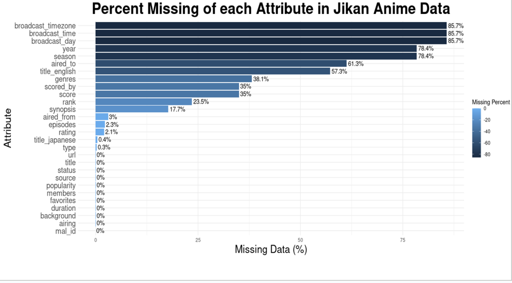

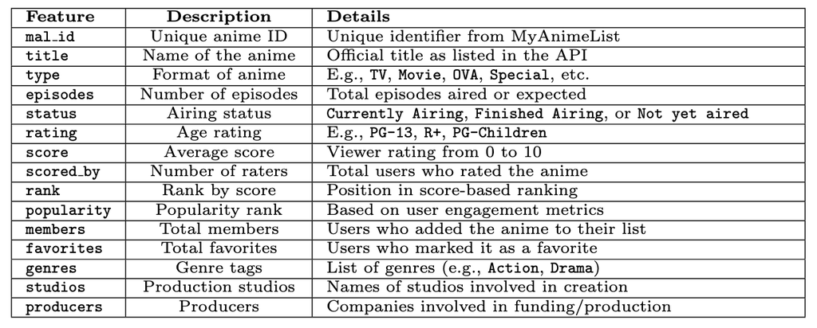

In the final preprocessing phase, we reduced the categorical variables in the “genre” field to 30 classifications. The top 10 most popular genres were selected and transformed using one hot encoding, which is a technique that facilitates more efficient and effective model training in subsequent predictive analysis phases.

# Exploratory Data Analysis

## Score Distribution And Outlier Analysis

In order to understand anime quality, we first examined the full distribution of anime scores within the dataset. Descriptive statistics revealed a minimum score of 1.88, with a first quartile at 5.78, median at 6.37, mean at approximately 6.40, third quartile at 7.04, and a maximum score of 9.30. The distribution indicated that most anime ratings clustered within a range of approximately 4 to 8, which demonstrates a relatively high overall quality perception among viewers. Additionally, by analyzing 102 outliers, we identified and quantified outliers to understand extremes in viewer perception. Among these outliers, a small subset displayed unusually low scores ranging from 2 to 4, which shows that there is significantly less viewer satisfaction or audience appeal compared to other high score outliers that are approaching the maximum rating.

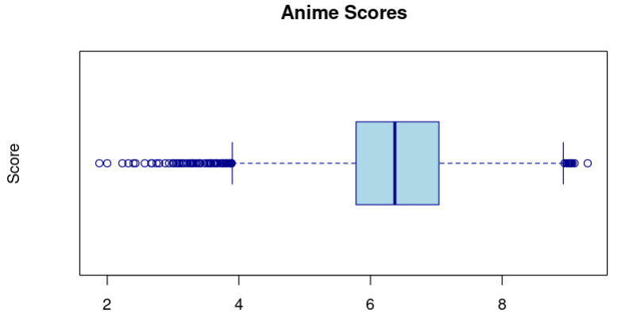

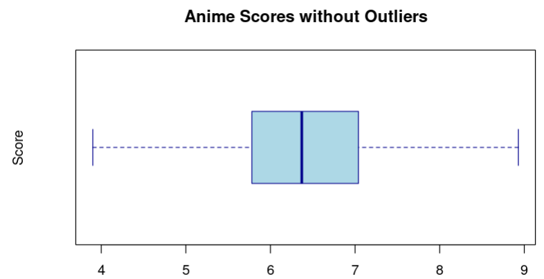

| Min | 1st Qu | Median | Mean | 3rd Qu. | Max |
| --- | --- | --- | --- | --- | --- |
| `1.880` | `5.780` | `6.370` | `6.398` | `7.037` | `9.300` |

## Analysis Of Anime Studios

We explored anime studios by examining the number of anime produced by each studio and their corresponding average scores in order to understand the relationship between studio productivity and perceived anime quality. Our analysis illustrates that studios producing large quantities of anime were generally the most widely recognized within the community. However, in contrast to expectations, studios that achieve the highest average viewer scores are lesser known small entities that only have one to three anime productions. Thus, this finding highlights an intriguing trend where smaller studios can achieve exceptionally high quality results despite the fact of their limited exposure or production volume.

## Distribution Of Scores by Anime Type

Since the anime entries are categorized into nine distinct types such as TV series, Movies, Specials, and OVAs, we decide to perform an analysis of variance to statistically examine whether these anime types differed significantly in average viewer scores. The ANOVA test yielded a highly significant p value of 2e-16, which demonstrates meaningful differences in perceived anime quality across types.

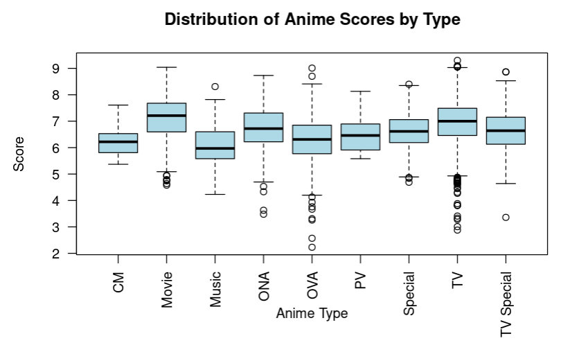

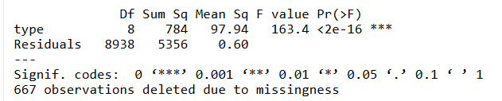

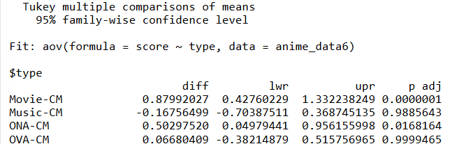

## Distribution of Scores By Content Rating

We conduct another analysis to examine average scores across anime content ratings. The ANOVA test also confirmed that there are statistically significant differences across categories. Further Tukey analysis detailed these differences, which reveals that almost all pairs of content rating groups have significantly distinct average scores since there are viewer differentiation based on content appropriateness and targeted audience segments. However, there are some exceptions between PG Children and G All Ages as well as between R Mild Nudity and G All Ages, which demonstrates that there are minimal perceived quality differences among these specific audience classifications. Hence, this suggests that content targeting broader audience groups or minimal age restrictions may share common viewer perceptions and quality expectations.

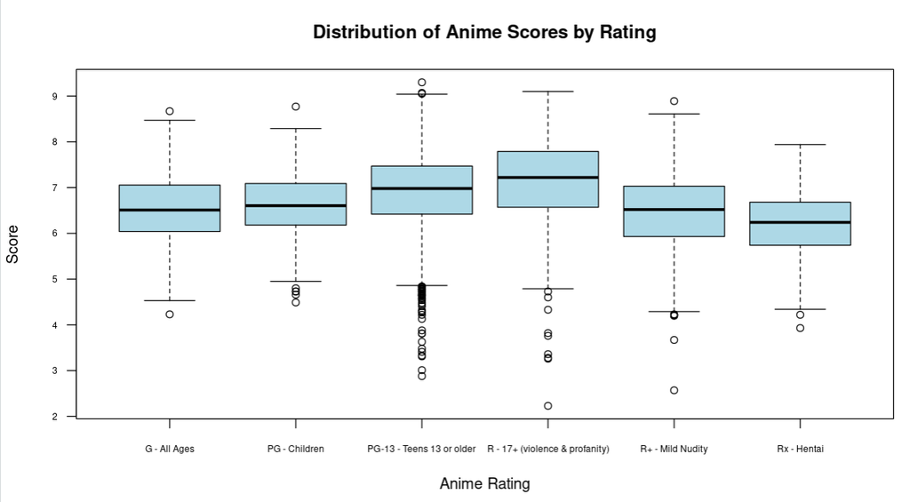

Explore Top Rated Anime Titles

In order to understand the top rated anime titles, we sort the dataset by viewer scores to highlight the highest scoring anime. We realize that these five animes share some characteristics in common; each of them incorporates compelling narrative structures within popular and widely appealing genres such as action, adventure, drama, fantasy, science fiction, and suspense. Additionally, these titles often demonstrate a combination of high production quality, strong storytelling, and well developed characters, which are factors frequently associated with audience satisfaction. With unique storytelling and emotionally resonant themes, these factors significantly enhances audience appreciation, which makes them exemplary representations of successful mainstream anime.

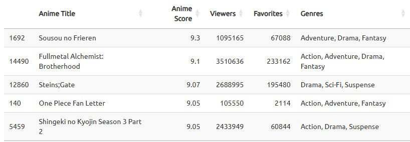

## Data Preprocessing For Predictive Analysis

To effectively prepare our dataset for predictive modeling, we implement several preprocessing steps to enhance clarity and optimize data dimensionality. Initially, we removed columns such as english titles and japanese titles because these served merely as unique identifiers for each anime entry, which lacks generalizable patterns suitable for modeling purposes. By removing these attributes, we simplified the dataset without sacrificing important analytical information.

For the studios attribute, we grouped studios based on both the quality and quantity of their productions. Studios producing at least 30 anime titles with an average score at or above the third quartile are categorized as top studios. Other studios were grouped as other in order to keep categorical variable concise.

Since the producers are slightly more complex on account of the fact that there are multiple producers typically being listed for each anime, we use text processing techniques to extract individual producer names and then apply similar grouping criteria to them. If any producer associated with an anime met the top criteria, then the anime will be labeled as a top producer. Otherwise, it was classified as other, which results in a more concise variable that is suitable for predictive analysis.

To further simplify and enhance interpretability, we regrouped the type and rating attributes based on statistical insights. Anime types are categorized into three groups of high, mid, and low. Similarly, ratings are reclassified into high, mid and low. Thus, these preprocessing significantly improved analytical clarity and supported more effective predictive modeling.

# Predictive Models

In this section, we utilize our preprocessed dataset to predict anime scores on a scale of 0 to 10. We decide to implement both linear regression and random forest algorithms in order to determine which one better suits this situation. For consistency, the dataset was randomly partitioned into training and testing sets with a predetermined seed value of 123 to ensure reproducibility of results. To optimize model performance, we use 10 fold cross validation for both algorithms, which involves training each model on nine partitions of the training data while evaluating performance on the remaining partition iteratively.

Our analytical framework follows a systematic procedure for each model. We first initial model fitting and evaluate performance on training data through visualization of predicted versus actual scores. We then perform subsequent assessment on the testing data. For the linear regression model, both training and testing plots revealed a sigmoid shaped relationship between predicted and actual scores, which suggest its potential limitations in capturing non linear patterns in the data.

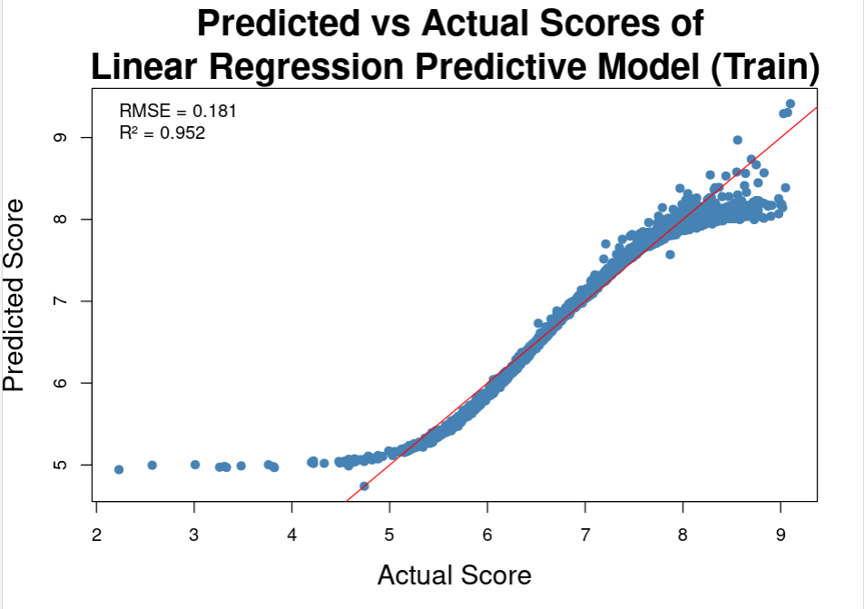

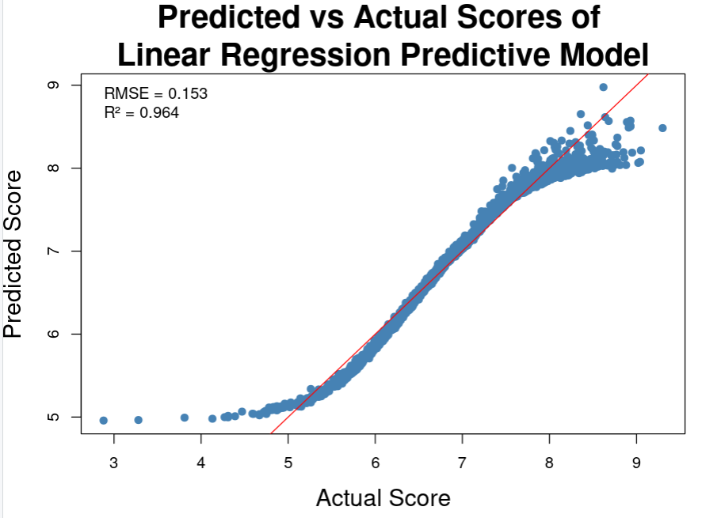

|  | RMSE | R^2 |
| --- | --- | --- |
| Train | `0.1810902` | `0.9518742` |
| Test | `0.153142` | `0.9635275` |

We also implement the random forest model by using the randomForest package in R. Within the train() function, we specified the number of trees ntree as 10 and set the importance parameter to TRUE to facilitate feature importance analysis.

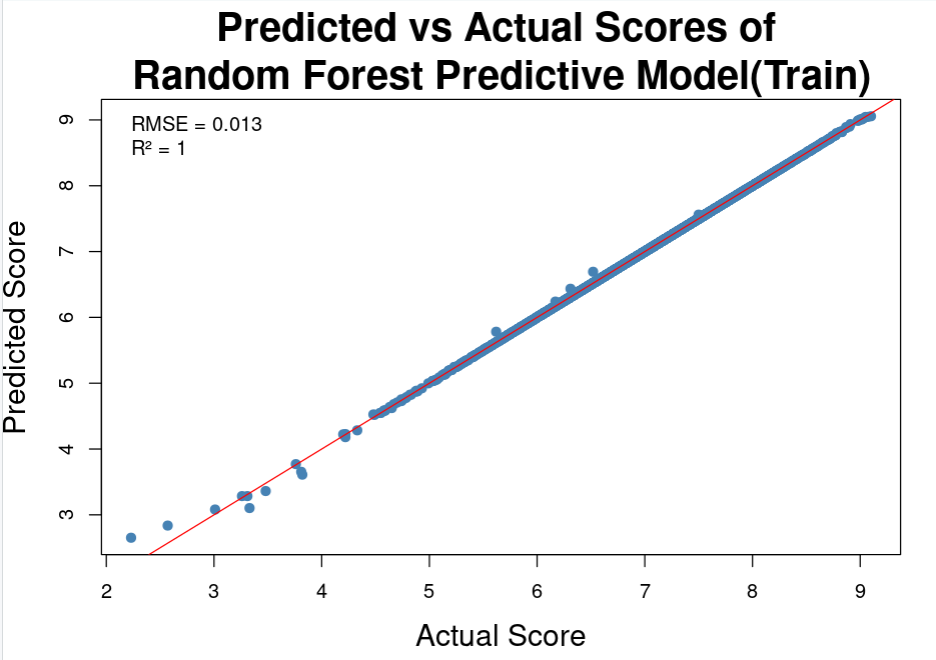

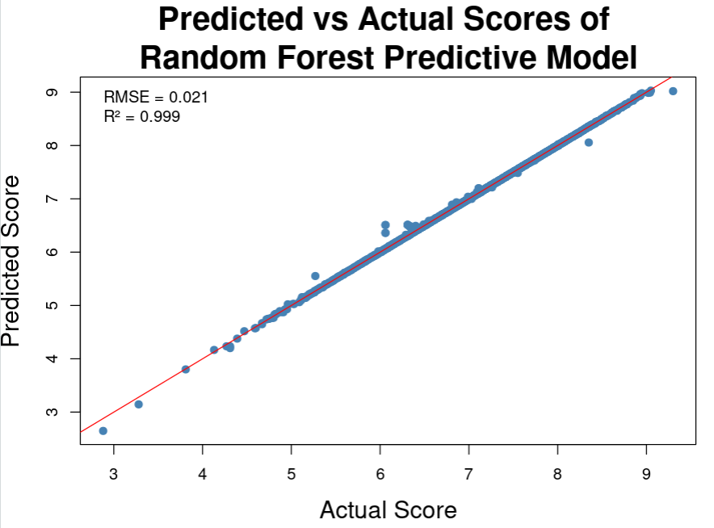

[output not shown]

# Data Visualizations And Findings

In order to answer the research questions that we are exploring earlier, we have constructed several data visualizations to help us better understand the relationship between different attributes in the dataset and their contribution to anime popularity.

## Relationship between Anime Scores and Viewership

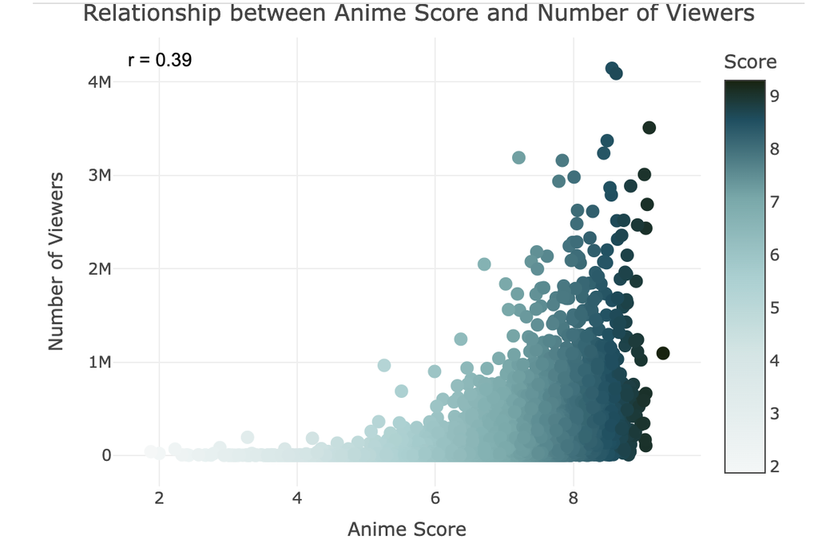

This scatterplot indicates the relationship between anime scores and number of viewers; it shows a moderate positive relationship between an anime’s score and its viewership as indicated by the correlation of 0.39. The scatterplot reveals a wide spread at the end as many anime with scores in the range between 7 to 9 have higher viewership. For instance, the most watched titles usually have solid scores around 7 or higher. There are also few instances showing highly popular with very low scores, which shows that extremely bad anime rarely becomes massively popular.

### Anime Score With Highest Number of Viewers (Q1.1)

A very high score does not always mean that an anime is widely watched. As shown in the bottom right clusters of dark points where they have a score range between 8 to 9 with under 500k or 100k viewers, we see numerous points with scores higher than 8 that have only average viewership.While a good score can help an anime gain popularity, other factors clearly influence popularity since a higher score only weakly correlates with more viewers.

### Why Do High Quality Series Remain Less Popular (Q1.3)

There are several reasons why a high quality series might remain less known compared to other ones. Age and availability play a big role because many high quality series are older anime that aired before the anime boom or never got released internationally. For instance, Ashita no Joe 2 is over 40 years old already. Despite its classic status among veterans, newer generations have limited exposure to it. Older shows often suffer from outdated animation style or simply aren’t marketed on modern streaming platforms, which leads them to underperform in terms of attracting viewers. In other cases, minimal marketing or distribution issues can keep quality series obscure. As a result, having a high score is not enough to guarantee popularity. Without accessibility, broad appeal, or marketing, even top tier anime can remain relatively less known.

### Common Characteristics Of Less Known High Quality Series (Q1.4 & Q1.5)

Based on observing some less known high quality series, we can spot some common characteristics among them. A lot of them tend to be older or classic series that never got the viral attention recent hits enjoy. Many were released in decades when the international anime fanbase was smaller or they belong to long running series that only dedicated fans follow into later seasons. These animes often come from specific genres since our analysis indicates that certain genres are often highly rated but not very popular like award winning, sports, or avant garde. For example, sports anime or certain titles frequently usually attract a smaller fan base compared to mainstream genres like shounen or action. A lot of the high score anime titles also require prior knowledge about their complex storylines. Thus, these animes often share traits like older release years, specific genres, and limited exposure which explains why their quality isn’t reflected in massive viewership.

### Popular Anime With Average Scores (Q1.6 & Q1.7)

Conversely, there are anime that attract huge viewership despite having relatively lower scores. These are often the trending series that everyone watches even if many consider them average in quality. A prime example is Sword Art Online where it has over 3.1 million members with an average score around 7.2. This average score shows that a lot of fans watch it for its popular premise despite mixed critical reception. In fact, Sword Art Online II attracts about 2 million viewers with a lower score of 6.7. We notice that a lot of trending animes spark huge discussion and trend on social media despite being considered just okay by critical viewers. This phenomenon often appears once an anime becomes overly popular; it will face a critical backlash that decreases its average score. Nonetheless, the outstanding popularity demonstrates that these shows succeed in grabbing attention even if their scores are not the highest.

## How Active Do Viewers Engage Based On Anime’s Popularity

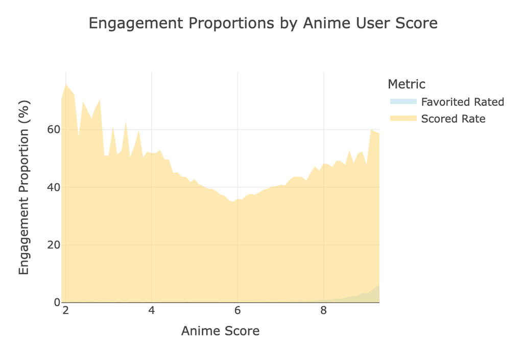

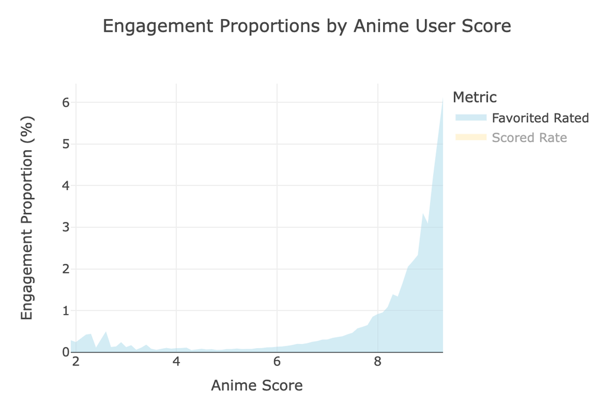

The graphs indicate a complex relationship between an anime’s popularity and how actively its viewers engage as measured by engagement activities. Viewers are most actively engaged through rating and favoriting when an anime resonates strongly with them, which is often correlated with the anime’s quality and its popularity. While popular anime gather a large number of engaged users, their engagement proportion may be affected by different viewers. On the other hand, anime with slightly smaller but passionate audiences can see disproportionately high engagement rates. As shown in the graphs, high score anime usually achieve high engagement ratios compared to average anime. Conversely, low score anime also achieve high engagement ratios due to fans complaining compared to average. In other words, anime popularity alone does not guarantee active discussion or feedback. Instead, the quality of an anime affects whether viewers engage very actively or not.

### Rating Participation And Audience Satisfaction (Q2.1)

A higher score percentage generally signals a more engaged audience. When a large fraction of viewers takes the time to score an anime, it suggests that the show left a strong impression that compels viewers to voice their opinion whether it is positive or negative. For instance, an anime where 80% of its viewers rated it likely inspired its audience to actively participate, reflecting engagement through both satisfaction and a sense of investment in the show’s quality. By contrast, if an anime’s scored percentage is low, it might indicate that many viewers felt indifferent or unmotivated to provide feedback due to the fact that the show failed to stand out. Thus, a high scored percentage often correlates with an engaged viewership that cared enough about the anime to record their opinion because they found the experience unforgettable.

### Popular Animes With High Viewships (Q2.2)

Animes with a large share of viewers does not always have the highest overall popularity. The graphs suggest that some animes with very high rating participation are not the ones with the biggest audiences. For example, an anime might have a relatively average member count with extremely high score percentage; it indicates that almost everyone who watched felt strongly enough to rate it. Another immensely popular title might have millions of viewers with an average score percentage due to the fact that many casual viewers did not engage beyond watching. High popularity sometimes affects the percentage of engaged feedback because the audience includes a broad mix of dedicated fans and passive viewers. Conversely, anime that appeal to a specific passionate community may achieve a high proportion of engagement without being mainstream hits. Thus, anime that inspire a large fraction of their viewers to rate them are often those that foster strong engagement, which can occur at any popularity level. High popularity and high engagement can happen at the same time but a large audience alone does not always guarantee that most viewers will participate in rating.

## The Most Popular Genres Based On Scores And Views

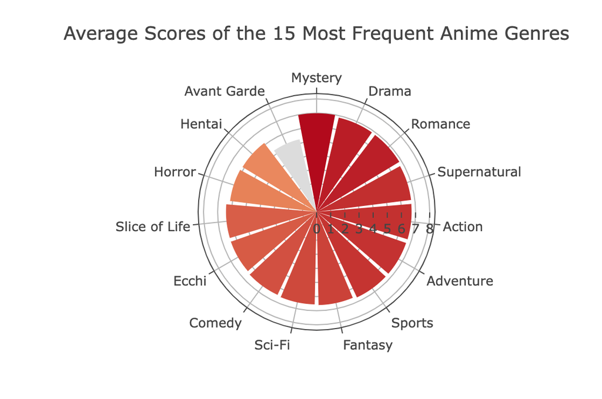

The success of mystery, drama, and romance suggests that anime creators and streaming platforms might strategically prioritize these genres on account of their viewership and positive audience engagement. As they consistently receive high scores, these genres illustrate a degree of predictability in viewer satisfaction, which makes them safer choices for future investments and marketing efforts. Moreover, the presence of these genres implies potential shifts or trends in viewer preference. Audiences today appear more inclined towards narrative complexity and emotional depth rather than purely visual pleasing or action driven storytelling alone. Hence, future anime productions aiming for broader viewership might benefit from integrating elements from these successful genres to optimize viewer reception and popularity. As a result, the radar chart effectively highlights the popularity of each genre and provides valuable insights about anime fans’ preferences. The consistently strong performance of these genres emphasizes their potential in anime market strategy, which could be utilized to guide streaming services and producers.

### Genres With Successful Shows (Q3.1)

The radar chart distinctly identifies genres such as mystery, drama, and romance as top tier genres that are performing well historically. Mystery anime’s high scores indicate its huge viewership for its suspenseful storytelling, and intellectual depth. Similarly, drama and romance maintain consistently high ratings by delivering emotional stories. The success of these genres have meaningful implications for streaming services and content producers. Platforms prioritizing these genres can attract viewers and reduce investment risks. Additionally, investing in these genres would foster long term fan bases. For anime fans, the consistent success of these genres provides significant reassurance. Fans who prefer these genres can confidently explore new titles because they are likely to meet high standards of storytelling and character development.

### Impact Of Popular Genres On Audience Numbers (Q3.2)

While the radar chart does not explicitly list harem or shounen, it provides useful insights by evaluating associated genres. The action genre is typically related to shounen, which exhibits darker color; it represents consistently positive viewer reception based on its high score. This implies that audiences widely appreciate shounen style anime by dynamic storytelling and adventurous themes. Conversely, Ecchi is closely related to the harem genre, which presents a noticeably lighter color. This indicates lower average viewer ratings compared to the action genre. The difference between these two popular categories provide useful information to both streaming platforms and anime fans.

Streaming platforms seeking broad market appeal and substantial audience growth may find greater success by focusing on shounen style action anime rather than relying heavily on ecchi or harem content. Prioritizing action related stores can engage wider and more diverse audiences. While harem or ecchi themed anime may cater to a dedicated subset of viewers, their narrower appeal may limit overall subscriber growth, which constrains revenue and content monetization opportunities. Platforms aiming for widespread adoption and mainstream success should strategically integrate shounen action elements into their homepages to effectively boost audience reach and enhance viewer engagement levels. For fans, this graph clarifies expectations regarding genre based content quality and popularity. Fans who are attracted to action and shounen content or ecchi and harem can utilize different streaming platforms to explore new animes based on their preferences.

### The Success Of Niche Genres (Q3.5)

The growing recognition and prioritization of these genres by streaming platforms yield substantial benefits for dedicated fan communities. As platforms increasingly cater to audiences of underrepresented genres, these audiences gain access to better content libraries featuring rare, culturally specific titles. Empirical studies suggest that such personalized engagement correlates with heightened emotional investment as fans perceive their tastes as institutionally acknowledged. Thus, this symbiotic relationship between platforms and fans diversifies the anime market and fosters a culture of inclusivity.

## The Correlation Between Top Tier Studios And High Score Anime

[figure not shown]

The chart provides valuable information for anime enthusiasts and the industry. For anime fans, knowing which studios consistently deliver quality can enhance their viewing experience because it is a guide to discovering anime that are likely to be enjoyable. The chart indicates some studios have been performing well historically, which is important for fan communities when discussing and recommending shows. For creators and studios, this analysis underlines the importance of maintaining a good track of record. A studio’s brand can influence its reception where a good reputation can create hype and initial goodwill for a show while a poor record might make viewers skeptical. For streaming platforms and publishers, recognizing these trends is equally important. Content from studios with high scores might be seen as high value IP; platforms may prioritize licensing shows from top tier studios knowing they are likely to attract viewership. Thus, the chart illustrates how studio identity, consistency, and reputation play a critical role in anime success. These insights are important to anime fans by guiding them toward quality content as well as creators and industry.

### Studios With High Score Animes (Q4.1)

These top tier studios illustrate a strong correlation between studio identity and anime quality. When a studio repeatedly produces beloved, highly scored series, it builds a reputation for excellence. Viewers come to trust that studio’s name as a mark of quality. If an anime is made by one of these studios, fans are likely to have higher expectations and interest. This creates a positive feedback loop because studios that are known for quality attract top talent and popular producers, which in turn leads to more popular shows. In summary, the chart highlights that certain studios consistently achieve high scores, which shows how a studio’s track record can influence an anime’s reception. A strong studio identity often contributes to anime success as seen with these high performing studios that repeatedly deliver high quality content.

Top Tier Studios And Their Performance (Q4.3)

Anime produced by top studios tends to attract more fans and achieve high scores. But maintaining high average scores becomes harder as the number of titles grows. The chart reveals an interesting relationship between a studio’s output size and its score. Studios with strong reputations often produce many famous shows even though their average scores can be lowered by the sheer number of titles.

### Studios With High Score Anime (Q4.4)

From the chart, we can identify a bunch of studios that have delivered multiple highly rated anime. These studios stand out for maintaining strong performance over several releases. In contrast, some studios on the chart have high averages largely due to one or two outstanding anime. For anime fans, this is important because it signals which studios they can count on for quality content time and again. If a studio like K Factory or Sharefun is attached to a new series, fans familiar with this data might expect another excellent show based on past performance. As a result, the chart showcases several studios that repeatedly produce high scoring anime. Identifying these reliable studios is valuable for viewers who want to find great shows more easily.

# Conclusion

Anime has rapidly transformed from a micro culture into a mainstream global phenomenon. In the past year, anime industry accounted for nearly 5% of worldwide audience demand as reflected in its growing market size. Our study systematically investigated the pattern behind anime’s global market expansion through analysis of content creation trends, genre dynamics, studio performance, and audience engagement. By exploring 18000 anime titles from the Jikan API, we employed exploratory analysis to understand the factors shaping the industry’s growth. These findings reveal valuable insights into the relationship between creative choices, studio reputation, and audience behavior.

## Key Findings And Valuable Insights

In addition, studio reputation significantly impacts audience expectations and engagement. Top tier studios such as KFactory limit their portfolios with visionary directors and writers to maintain artistic integrity. In contrast, larger studios like Toei Animation face several challenges on account of their popular shows. For example, Dragon Ball Super with a score of 7.1 underperformed significantly compared to its previous series Dragon Ball Z with a score of 8.3, which highlights the obstacles of maintaining their high reputation among their fans. Although smaller studios such as Nippon Ramayana Film demonstrate its unprecedented success with innovative storytelling, such instances remain rare due to resource constraints and market saturation.

Moreover, the format of anime content plays a role in its global expansion. TV series, which make up most of the anime in the study, usually get the most attention from fans around the world. These series can tell longer stories and develop characters over many episodes, which helps build big, loyal fan groups. On the other hand, shorter anime like OVAs, specials, or movies usually have smaller audiences. Even though movies and OVAs often get high ratings because dedicated fans love them or they have better quality per episode, they usually stay popular only with smaller groups unless they’re widely available. Despite the fact that long TV series are the main way to grow fans around the world, movies and OVAs are still important because there are fans who already love the series or find them later on streaming services.

## Improve Anime Global Market Expansion

Based on these insights, we noticed that there is a huge gap between what fans love and what most anime fans actually watch. Take Legend of the Galactic Heroes as an example, with an incredible 9.01 score, it only has about 342,000 viewers. Due to its older animation style and complicated storylines, it requires viewers to understand its sophisticated background before watching it. Meanwhile, even though Demon Slayer has a slightly lower score of 8.7, it has a massive fan base of 3.8 million viewers. These mainstream animes succeed by focusing on stunning visuals and straightforward stories as well as social media promotion and global streaming advertising to reach as many people as possible. Unfortunately, this problem gets worse because of how anime is distributed today. Many brilliant older classics like Rose of Versailles are not available on major streaming platforms, which means newer anime fans never discover them. At the same time, services like Crunchyroll and Netflix keep pushing recent shows that work well with their algorithms, which pushes less popular animes further into the shadows.

Based on the current global anime market, there are several practical ways that it can continue to grow. Industry stakeholders need to overcome key challenges like limited distribution, poor promotion of less known titles, and streaming platform biases. Making less known anime more accessible through reworking older works is crucial. For instance, Netflix’s successful revival of Neon Genesis Evangelion shows how effective this approach can be. With better localization with multiple language options and quick simulcast releases, it helps to build and expand international fan communities. Forming strategic international partnerships also offers significant growth potential. With collaborations between Netflix and studios like MAPPA and Mir, producers could have bigger budgets, better global distribution, and wider audience reach. Japan’s Cool Japan initiative and international festival appearances further expand anime’s global footprint. Improving recommendation algorithms to highlight lesser known titles, combined with smart social media marketing and influencer collaborations will attract diverse global audiences. Therefore, these approaches can establish anime as a mainstream global entertainment medium with lasting industry growth and cultural impact.

As one can see, our analysis of anime genres, studio influence, audience engagement, and distribution frameworks offers a comprehensive understanding of the key factors driving anime’s international success. Anime’s global popularity comes from its amazing content and its spread among different people around the world. Great stories, interesting genres, and high quality contents are at the heart of a successful anime. In order to keep expanding globally with tremendous success, anime needs to be marketed more effectively so that more people will know about it and access it easily. By learning from these insights, people in the anime industry can come up with plans to reach more fans and make the world of anime entertainment even richer and more diverse. This way, anime will stay exciting and popular all over the world, keeping current fans happy and attracting new ones for a long time. By learning from these experiences, companies in the industry can develop plans that help them reach more people and add to the variety of entertainment options for anime fans worldwide, which helps current fans to discover more contents and attract new fans across the world.

# Future Improvements

As the global anime market continues its expansion, our proposed platform offers various benefits to both anime fans and stakeholders. However, as entertainment technology and consumer behavior rapidly evolves, we hope to extend our research to improve the user experience and address specific limitations in our current platform. Based on our preliminary analysis and research, we have identified several plans that can be implemented in the near future.

## Large Language Model Integrations And Machine Learning Algorithms

With thousands of anime titles available, apps with personalized recommendation services that understand each individual’s tastes become extremely viral. Modern streaming platforms have shown the power of this approach where Netflix reported that users discover “around 80 percent of shows” through its recommendations system (Bischoff, 2024). While our current platform effectively recommends top tier animes to users based on users’ preferences on genres, we plan to build a better recommendation system that requires more sophisticated information about anime rather than solely relying on generes.

By learning from a fan’s viewing history, favorite genres, characters, and even art styles, a fine tuned large language model system can highlight hidden gems that a user might otherwise overlook. For example, if a viewer consistently enjoys anime with strong female protagonists or a particular art style, the recommendation engine can detect those patterns and surface lesser known titles with similar attributes. This level of personalization improves the user experience by making the search for the next show effortless; it also helps specific producers to find their ideal audience or a fan who is interested in specific subgenres to find his new anime rather than only popular mainstream hits.

Recent advances in natural language processing offer promising approaches for extracting different features from both anime synopsis and viewers’ comments. By implementing multimodal neural networks trained specifically on anime content, we aim to develop systems that recognize different narrative and emotional patterns that traditional classification methods lack. As shown in Tran’s recent work, machine learning algorithms and trained classifiers are able to identify distinctive stylistic patterns in different anime based on “various lexical, syntactic, and readability features” with extremely high accuracy during testing (Tran et al., 2024). Similarly, sequence to sequence models trained on scripts have shown remarkable success in capturing narrative elements. Since producers often use flashbacks or non linear storytelling to “pertain emotional impact” on audiences, these patterns can be computationally detected and utilized to make better recommendations to our users (DeGuzman, 2024).

By integrating these techniques, we aim to develop a better system that provides viewers with dynamic suggestions based on their preference in real time. As the recommendation algorithms become more sophisticated, they can capture subtle aspects of user preference through deep learning and contextual data. For the stakeholders, this means longer viewer retention and more opportunities to connect fans with content they love, which opens doors for older or less known titles to find new life with receptive viewers. As one can see, artificial intelligence based recommendation systems offer personalized tools for both anime fans and investors.

## Multimedia Performance Evaluation

The anime industry today spans multiple media platforms from original manga and light novels, to animated series, films, video games, and a vibrant online fandom on social networks and forums. Different media formats are often closely intertwined where a popular manga might be adapted into an anime series or the success of an anime might boost the sales of its original light novel. We plan to incorporate anime’s performance across different media by linking anime with their source manga and light novels. With systematic analysis performance across these media, researchers and industry stakeholders can uncover how success in one format impacts the other. For instance, the rise of an anime adaptation often drives readers to seek out the original manga as shown in Demon Slayer: Kimetsu no Yaiba. It skyrocketed “20 million copies” from “5 million copies” within a short time frame after its anime adaptation in 2019 (Peters, 2024). This means that a successful anime generates revenue through viewership as well as other media sources.

The app would continuously monitor engagement across social networks and fan communities. In the digital age, social media engagement is considered a “compelling indicator” of a show’s performance (Atherton, 2024). Metrics like trending hashtags, likes, shares, and forum posts can serve as benchmarks of community passion in real time. By aggregating X, TikTok, Instagram, Reddit, and specialized anime forum data, we aim to build a new feature in our app to collect both positive and negative reactions in order to identify which characters or story are generating topics. Fan forum discussions also reveal the fans’ perspectives where threads about manga plot or anime announcements can be used to conduct sentiment analysis across channels to further improve our recommendation systems.

Instead of scattered information where one app for anime tracking, one app for manga, and separate websites for news or fan discussions, our platform aims to become a well organized anime hub where fans can access a chronology of releases and story content across media. For example, our app could have a timeline tab showing when each manga volume, anime episode, novel, or movie released in relation to each other. This helps fans navigate complex storylines and ensures they don’t miss any part of the narrative. Additionally, investors and distributors can use these cross platform data to estimate potential growth of an anime before committing funds. By comparing metrics like social media engagement per chapter released, stakeholders will be able to make correct decisions; it also helps streaming platforms to determine which new anime license will attract subscribers in different regions.

## User Contributed Database

Maintaining a comprehensive anime database is a daunting task for any organization. By enabling qualified user contributions to the database with a robust verification system, the community of knowledgeable fans can collectively expand and refine the anime database while maintaining data integrity. Based on the success of open source platforms like Wikipedia that has accumulated “6,987,642 articles” through volunteer editing, data from qualified fans can dramatically speed up the growth of the database, keeping the entire database continuously up to date (Wikimedia Foundation, 2025).

As anime continues to grow globally, no single research team or database can keep pace with all the new releases, different editions, and ambiguous data. We plan to allow dedicated fans, scholars, or industry experts to contribute additional data or corrections such as submitting missing information such as a newly announced anime, updating broadcast time in a region, or correcting an error in the current database. To ensure data integrity, we will also implement rigorous verification processes so that each user contribution would be carefully reviewed before it is officially integrated, which is similar to how open sourced data platforms with editorial review.

Furthermore, the collaborative nature of the database creates opportunities among anime enthusiasts since it fosters a sense of collective ownership and potentially reduces the fragmentations that are commonly seen across different platforms and forums. This integrated database also benefits industry stakeholders by creating more organized and identifiable consumer groups. With accurate and real time details about content popularity or distribution, stakeholders can inform decisions rather than solely waiting for quarterly reports; they can facilitate more effective product development and marketing strategies aligned with actual fan interests instead of assumed preferences. As a result, by combining the passion and specialized knowledge of fans with rigorous verification standards and sophisticated data structures, we can create a more detailed anime database that supports the continued growth of anime as a global cultural phenomenon and apply this workflow to other entertainment domains.

## Global Expansion And Creator Support

With a growing market across different continents and diverse demographics, we plan to include multilingual support with subtitles and dubs in multiple languages as well as customized user interface and community guidelines for different regions. Hence, collaborations with local distributors or networks can help bring different content onto the platform under proper licensing. For instance, Crunchyroll has “more than 130 million users in more than 200 countries” where it translates anime into numerous languages so that fans can enjoy content in their preferred format (Purini, 2024). Similarly, our platform could aim to simulcast new episodes globally with better translation and unique local forums.

## Live Event Integration And Virtual Conventions

Integrating live events into our system would bridge the gap between digital and real world fandom experiences. This system can serve as an interactive event portal that allows users to discover and participate in anime conventions, creator panels, and fan meetups directly through the interface. For example, a fan could purchase a ticket to an upcoming anime convention through our platform and receive a personalized schedule of panels, workshops, and autograph sessions. Our platform will also send reminders and real-time updates like changes in panel timings to ensure that attendees get the most out of the event.

As one can see, the proposed future plans will transform our platform into a well organized anime hub for both anime fans and industry stakeholders. Instead of merely delivering content, our platform bridges the gaps between diverse user groups, including passionate anime fans, content creators, industry stakeholders, and global markets. By integrating immersive and interactive digital experiences that foster meaningful community interactions, this platform will become a place where fans can deepen their connections and shared passions rather than a simple content delivery system. By constantly improving the current system and implementing new features, our anime platform establishes a new milestone for how digital media can bring people across the world together with something that they are passionate about.

# Reference

Bali, V. (2025, March 19). *The global anime market size was USD 28.8 billion in 2023!*. Cognitive Market Research. https://www.cognitivemarketresearch.com/anime-market-report

Shinde, Y. (2024, July 3). *Anime market trends: A journey towards USD 74.8 bn*. Market.us Scoop. https://scoop.market.us/anime-market-news/

Dyck, S. O. P. R. (2024, September 6). *Should Christians watch anime? A discernment guide*. Pauline.org. https://pauline.org/media-mindfulness/should-christians-watch-anime-a-discernment-guide/

Razak, S. (2025, January 9). *Exploring the world of Anime*. prezi.com. https://prezi.com/p/8jc6oob9utvq/exploring-the-world-of-anime/

Ferjan, M. (2024, January 8). *20+ Anime Statistics & Facts: How many people watch anime? (2025)*. HeadphonesAddict. https://headphonesaddict.com/anime-statistics/

Pace-McCarrick, S. (2021, December 16). How far does anime challenge Joseph Nye’s “Soft power” and its approach to culture? E-International Relation. https://www.e-ir.info/2021/12/11/how-far-does-anime-challenge-joseph-nyes-soft-power-and-its-approach-to-culture/

Iwabuchi, K. (2002, November 8). Recentering globalization. De Gruyter Brill. https://www.degruyterbrill.com/document/doi/10.1515/9780822384083/html

Fennell, D., Liberato, A. S. Q., Hayden, B., & Fujino, Y. (2013, September 1). *Consuming anime*. The Aquila Digital Community. https://aquila.usm.edu/fac_pubs/8302/

Mash, M. (2024, September 4). The global impact of japanese animation: How anime shaped pop culture. ALC Atlantis. https://alc-atlantis.com/the-global-impact-of-japanese-animation-how-anime-shaped-pop-culture/

Scottnicole, S. (2024, January 17). *Psychological benefits of Cosplay*. The Urban Crews. https://www.theurbancrews.com/lifestyle/cosplay-psychological-benefits/

Hulu - Anime News Network. (2025, April 26). Animenewsnetwork.com. https://www.animenewsnetwork.com/encyclopedia/company.php?id=6901

Tran, V. H., Sebastian, Y., Karim, A., & Azam, S. (2024, December 5). Distinguishing human journalists from artificial storytellers through stylistic fingerprints. MDPI. https://www.mdpi.com/2073-431X/13/12/328

DeGuzman, K. (2024, April 17). Non-linear plots - how to write stories out of order. StudioBinder. https://www.studiobinder.com/blog/what-is-a-non-linear-plot-definition/

Bischoff, M. (2024, February 20). How recommendation algorithms work–and why they may miss the mark. Scientific American. https://www.scientificamerican.com/article/how-recommendation-algorithms-work-and-why-they-may-miss-the-mark/#:~:text=Whether%20we%E2%80%99re%20using%20Spotify%2C%20Amazon%2C,For%20example%2C%20the

Peters, M. (2024, October 5). Here’s how demon slayer’s anime boosted the manga sales. ComicBook.com. https://comicbook.com/anime/news/demon-slayer-anime-influence-manga-sales-boost/#:~:text=In%20terms%20of%20numbers%2C%20Demon,all%20thanks%20to%20the%20anime

Atherton, M. T. (2024, April 18). *Anime’s outsized impact on social media, quantified*. Anime Trending | Your Voice in Anime! https://www.anitrendz.com/news/2024/04/19/animes-outsized-impact-on-social-media-quantified

Wikimedia Foundation. (2025, April 22). Statistics. Wikipedia. https://en.wikipedia.org/wiki/Wikipedia:Statistics#:~:text=As%20of%20April%202025%2C%20the,encyclopedic%20text%20is%20added

Purini, R. (2024, July 3). Sony Group Portal - Crunchyroll’s mission to be the ultimate destination for anime fans. Sony Group Portal - Home. https://www.sony.com/en/SonyInfo/blog/2024/07/03/